# Le' Sean Roberts

## CUNY New York City College Of Technology Almuni (Graduate)

## Data Wrangling and Statistical Programming Specialist

Email

[LinkedIn](https://www.linkedin.com/in/le-sean-roberts/)

[GitHub](https://github.com/LeSeanRoberts)

## NYC Emergency Data Science Analysis for Emergencies Incidents

### Synopsis

This study leverages the New York City "Emergency Response Incidents" dataset—a comprehensive record of incident types and locations managed by the Office of Emergency Management (OEM)—to demonstrate the full lifecycle of a modern data science project. The analysis begins with data wrangling, transforming raw administrative logs into a structured format suitable for computation. Utilizing statistical programming (Python), wstatistical models are implemented to quantify the frequency and distribution of emergencies across the five boroughs. Furthermore, the study applies unsupervised learning techniques, such as K-prototypes clustering, to identify hidden spatial orientation and categorical groupings within the incident types. The results provide a data-driven framework for optimizing urban resource allocation and enhancing public safety response strategies.

### Introduction

The management of emergency response in a dense metropolitan area like New York City generates vast quantities of high-velocity data. The NYC Open Data portal’s Emergency Response Incidents dataset provides a critical window into this ecosystem, capturing variables such as Incident Type, Borough, Location, and Timestamp. However, the transition from raw data to actionable intelligence requires a rigorous methodological approach encompassing data preparation, rigorous modeling, and exploratory machine learning.

### Data Wrangling and Statistical Programming

Before any analytical insights can be gleaned, the dataset must undergo extensive data wrangling. Raw incident logs often contain inconsistencies in address formatting, missing timestamps, and redundant categorical labels (e.g., "Fire" vs. "Structure Fire"). Using statistical programming environments—primarily \Python (with Pandas)— to automate the cleaning process. This involves parsing date-time strings into computable objects, geocoding addresses for spatial analysis, and filtering "noisy" data points to ensure the integrity of the downstream analysis.

### Statistical Models

Once the data is structured, statistical models are employed to observe association among established categorical attributes. Such is accomplished with application of the Chi Square test, Cramver's V, and residual measures. These models allow one to determine if certain areas of the city experience statistically significant "hotspots" of specific emergency types.

### Unsupervised Learning

While supervised models help predict known outcomes, unsupervised learning offers a way to discover latent structures within the NYC emergency landscape. In this study, to utilize clustering to group incidents based on spatial coordinates, uncovering "emergency profiles" that may not be apparent through traditional reporting.

### Data Assimilation

```python
! pip install sodapy
```

```python
import pandas as pd
from sodapy import Socrata

DOMAIN = "data.cityofnewyork.us"
DATASET_ID = "pasr-j7fb"

APP_TOKEN = None  # put your token here for higher limits (recommended)

client = Socrata(DOMAIN, APP_TOKEN, timeout=60)

limit = 50000   # max rows per request Socrata allows
offset = 0
all_rows = []

while True:
    rows = client.get(DATASET_ID, limit=limit, offset=offset)
    if not rows:
        break

    all_rows.extend(rows)
    offset += limit
    print(f"Downloaded {offset:,} rows...")

client.close()

# Build dataframe
df = pd.DataFrame.from_records(all_rows)

# Optional: convert numeric/date columns automatically
df = df.convert_dtypes()

print(df.shape)
print(df.head())
```

```
WARNING:root:Requests made without an app_token will be subject to strict throttling limits.
```

```
Downloaded 50,000 rows...
(11750, 7)
                  incident_type                       location    borough  \
0            Utility-Water Main               136-17 72 Avenue     Queens
1  Structural-Sidewalk Collapse                   927 Broadway  Manhattan
2                 Utility-Other                           <NA>  Manhattan
3          Administration-Other  Seagirt Blvd & Beach 9 Street     Queens
4         Law Enforcement-Other                           <NA>   Brooklyn

             creation_date           latitude           longitude closed_date
0  2017-01-16T13:13:38.000  40.71400364095638  -73.82998933154158        <NA>
1  2016-10-29T12:13:31.000  40.71442154062271  -74.00607638041981        <NA>
2  2016-11-22T08:53:17.000               <NA>                <NA>        <NA>
3  2016-11-14T15:53:54.000  40.71400364095638  -73.82998933154158        <NA>
4  2016-10-29T17:35:28.000               <NA>                <NA>        <NA>
```

```python
df = df.dropna()
df.info()
```

```
<class 'pandas.core.frame.DataFrame'>
Index: 7314 entries, 11 to 11748
Data columns (total 7 columns):
 #   Column         Non-Null Count  Dtype
---  ------         --------------  -----
 0   incident_type  7314 non-null   string
 1   location       7314 non-null   string
 2   borough        7314 non-null   string
 3   creation_date  7314 non-null   string
 4   latitude       7314 non-null   string
 5   longitude      7314 non-null   string
 6   closed_date    7314 non-null   string
dtypes: string(7)
memory usage: 457.1 KB
```

```python
df
```

|  | incident_type | location | borough | creation_date | latitude | longitude | closed_date |
| --- | --- | --- | --- | --- | --- | --- | --- |
| 11 | Fire-3rd Alarm | 581 3 ave | new york | 2016-11-30T00:25:38.000 | 40.66748970288859 | -73.99428600039778 | 2016-11-30T04:22:22.000 |
| 53 | Rescue-Technical | 81-10 134 Street | Queens | 2016-11-22T12:24:02.000 | 40.71400364095638 | -73.82998933154158 | 2016-11-22T18:27:30.000 |
| 102 | Utility-Gas Low Pressure | Noble Avenue & Watson Avenue | Bronx | 2017-01-30T21:47:09.000 | 40.82730091310776 | -73.86917897682753 | 2017-02-10T19:40:58.000 |
| 120 | Utility-Other | 434 Beach 54 Street | Queens | 2017-01-09T12:54:45.000 | 40.71400364095638 | -73.82998933154158 | 2017-01-10T04:22:29.000 |
| 135 | Utility-Power Outage | 2800 W 5 St | Brooklyn | 2016-11-18T14:13:08.000 | 40.57967988661858 | -73.97190927609142 | 2016-11-18T23:31:39.000 |
| ... | ... | ... | ... | ... | ... | ... | ... |
| 11731 | Fire-6th Alarm | 324 East 93rd | Manhattan | 2016-10-27T03:40:16.000 | 40.71442154062271 | -74.00607638041981 | 2016-11-23T10:01:23.000 |
| 11732 | Utility-Manhole | 924 2 Ave | Manhattan | 2016-11-29T20:13:15.000 | 40.71442154062271 | -74.00607638041981 | 2016-11-30T00:56:28.000 |
| 11734 | Fire-High Rise | 60 wall street | manhattan | 2017-05-16T21:05:34.000 | 40.71442154062271 | -74.00607638041981 | 2017-05-16T21:39:54.000 |
| 11739 | Fire-2nd Alarm | 1436 Clay Avenue | Bronx | 2022-06-29T07:46:02.000 | 40.8376328185376 | -73.90720720119178 | 2022-06-29T11:04:23.000 |
| 11748 | Law Enforcement-Suspicious Package | JFK AIrport | Queens | 2016-11-14T11:25:49.000 | 40.64384687010468 | -73.78029486811537 | 2016-11-14T12:55:08.000 |

7314 rows × 7 columns

### The Main Issues

1. As mentioned earlier, Socrata returns everything as Strings (JSON) by default.
2. The 'latitude' and 'longitude' columns are string types. Instead they should be float for accuracy concerning computational and statistical purposes.
3. Instances for the 'borough' column are rightfully strings, however, there's possible issues with mispellings, capital letters, lower case letters. Furthermore, the excessive granularity applied involving location within a borough; latitude and longitude measures should already provide accuracy for location.
4. High granularity applied in the 'incident_type' column. Such to be first demonstrated.

#### Treating the High Granularity Issue in the 'incident_type' Attribute:

```python
unique_types = df["incident_type"].sort_values().unique()
print(len(unique_types), "unique incident types")
print(unique_types)
```

```
375 unique incident types
<StringArray>
[         'Administration-1 PP Activation',
                    'Administration-Drill',
        'Administration-Equipment Failure',
         'Administration-Evacuation Drill',
              'Administration-Injured CIC',
                  'Administration-Meeting',
          'Administration-NYPD Assistance',
 'Administration-OEM Assistance Requested',
         'Administration-OEM Involved MVA',
                    'Administration-Other',
 ...
                      'Utility-Water Main',
                      'Utility-Water Pipe',
              'Utility-Water Service Line',
               'Weather-Evacuation ZONE A',
                        'Weather-Flooding',
                       'Weather-Lightning',
                            'Weather-Rain',
             'Weather-Tropical Depression',
                  'Weather-Tropical Storm',
                            'Weather-Wind']
Length: 375, dtype: string
```

Acquiring the explicit full list:

```python
for v in sorted(df["incident_type"].unique()):
    print(v)
```

```
Administration-1 PP Activation
Administration-Drill
Administration-Equipment Failure
Administration-Evacuation Drill
Administration-Injured CIC
Administration-Meeting
Administration-NYPD Assistance
Administration-OEM Assistance Requested
Administration-OEM Involved MVA
Administration-Other
Administration-Planned Event
Administration-Social Media
Administration-Warehouse Alarm
Administration-Watch Commander In Hospital
Aviation-Helicopter
Aviation-Large Aircraft
Aviation-Other
Aviation-Passenger Aircraft
Aviation-Small Aircraft
Fire-10-76 (Commercial High Rise Fire)
Fire-10-76 (Commercial High Rise)
Fire-10-77 (Residential High Rise Fire)
Fire-10-77 (Residential High Rise)
Fire-1st Alarm
Fire-2nd Alarm
Fire-3rd Alarm
Fire-4th Alarm
Fire-5th Alarm
Fire-6th Alarm
Fire-7th Alarm
Fire-8th Alarm
Fire-Brush
Fire-Brush Fire 2nd Alarm
Fire-Brush Fire 2nd Alarm Fire
Fire-Building Evacuation
Fire-Collapse
Fire-Commercial
Fire-Crane Fire
Fire-Drill
Fire-Electrical
```

[output cut: 320 more lines]

```
Utility-Tractor Trailer into Sinkhole
Utility-Transformer
Utility-Transformer Fire
Utility-Water Condition
Utility-Water Leak
Utility-Water Main
Utility-Water Pipe
Utility-Water Service Line
Weather-Evacuation ZONE A
Weather-Flooding
Weather-Lightning
Weather-Rain
Weather-Tropical Depression
Weather-Tropical Storm
Weather-Wind
```

Of consequence, to resort to a more broad labelling or mapping. To now create a braod labelling dictionary:

$$ \begin{array}{ll} \hline \textbf{Incident Type} & \textbf{Macro Category} \\ \hline \text{Fire} & \text{Emergency} \\ \text{HazMat} & \text{Emergency} \\ \text{Rescue} & \text{Emergency} \\ \hline \text{Utility} & \text{Infrastructure} \\ \text{Structural} & \text{Infrastructure} \\ \hline \text{Transportation} & \text{Transport} \\ \text{Marine} & \text{Transport} \\ \text{Aviation} & \text{Transport} \\ \hline \text{Law Enforcement} & \text{Security} \\ \text{Medical} & \text{Medical} \\ \text{Administration} & \text{Administrative} \\ \text{Weather} & \text{Weather} \\ \text{Other} & \text{Other} \\ \hline \end{array} $$

```python
col = "incident_type"

df["incident_category"] = (
    df[col]
        .str.split("-", n=1)
        .str[0]
        .str.strip()
        .replace({
            "LawEnforcement": "Law Enforcement"
        })
)



macro_map = {
    "Fire": "Emergency",
    "HazMat": "Emergency",
    "Rescue": "Emergency",

    "Utility": "Infrastructure",
    "Structural": "Infrastructure",

    "Transportation": "Transport",
    "Marine": "Transport",
    "Aviation": "Transport",

    "Law Enforcement": "Security",

    "Medical": "Medical",
    "Administration": "Administrative",
    "Weather": "Weather",
    "Other": "Other"
}

df["incident_macro"] = df["incident_category"].map(macro_map)
```

```python
for v in sorted(df["incident_macro"].unique()):
    print(v)
```

```
Administrative
Emergency
Infrastructure
Medical
Other
Security
Transport
Weather
```

```python
for w in sorted(df["incident_category"].unique()):
    print(w)
```

```
Administration
Aviation
Fire
HazMat
Law Enforcement
Marine
Medical
Other
Rescue
Structural
Transportation
Utility
Weather
```

```python
df
```

|  | incident_type | location | borough | creation_date | latitude | longitude | closed_date | incident_category | incident_macro |
| --- | --- | --- | --- | --- | --- | --- | --- | --- | --- |
| 11 | Fire-3rd Alarm | 581 3 ave | new york | 2016-11-30T00:25:38.000 | 40.66748970288859 | -73.99428600039778 | 2016-11-30T04:22:22.000 | Fire | Emergency |
| 53 | Rescue-Technical | 81-10 134 Street | Queens | 2016-11-22T12:24:02.000 | 40.71400364095638 | -73.82998933154158 | 2016-11-22T18:27:30.000 | Rescue | Emergency |
| 102 | Utility-Gas Low Pressure | Noble Avenue & Watson Avenue | Bronx | 2017-01-30T21:47:09.000 | 40.82730091310776 | -73.86917897682753 | 2017-02-10T19:40:58.000 | Utility | Infrastructure |
| 120 | Utility-Other | 434 Beach 54 Street | Queens | 2017-01-09T12:54:45.000 | 40.71400364095638 | -73.82998933154158 | 2017-01-10T04:22:29.000 | Utility | Infrastructure |
| 135 | Utility-Power Outage | 2800 W 5 St | Brooklyn | 2016-11-18T14:13:08.000 | 40.57967988661858 | -73.97190927609142 | 2016-11-18T23:31:39.000 | Utility | Infrastructure |
| ... | ... | ... | ... | ... | ... | ... | ... | ... | ... |
| 11731 | Fire-6th Alarm | 324 East 93rd | Manhattan | 2016-10-27T03:40:16.000 | 40.71442154062271 | -74.00607638041981 | 2016-11-23T10:01:23.000 | Fire | Emergency |
| 11732 | Utility-Manhole | 924 2 Ave | Manhattan | 2016-11-29T20:13:15.000 | 40.71442154062271 | -74.00607638041981 | 2016-11-30T00:56:28.000 | Utility | Infrastructure |
| 11734 | Fire-High Rise | 60 wall street | manhattan | 2017-05-16T21:05:34.000 | 40.71442154062271 | -74.00607638041981 | 2017-05-16T21:39:54.000 | Fire | Emergency |
| 11739 | Fire-2nd Alarm | 1436 Clay Avenue | Bronx | 2022-06-29T07:46:02.000 | 40.8376328185376 | -73.90720720119178 | 2022-06-29T11:04:23.000 | Fire | Emergency |
| 11748 | Law Enforcement-Suspicious Package | JFK AIrport | Queens | 2016-11-14T11:25:49.000 | 40.64384687010468 | -73.78029486811537 | 2016-11-14T12:55:08.000 | Law Enforcement | Security |

7314 rows × 9 columns

#### Treating the String Type Issue for the 'latitude' and 'longitude' Columns. Transforming to Float:

```python
import pandas as pd

# Convert 'latitude' to float
df['latitude'] = pd.to_numeric(df['latitude'], errors='coerce')

# Convert 'longitude' to float
df['longitude'] = pd.to_numeric(df['longitude'], errors='coerce')

# Checking the data types to confirm the change
print(df.dtypes)
```

```
incident_type        string[python]
location             string[python]
borough              string[python]
creation_date        string[python]
latitude                    Float64
longitude                   Float64
closed_date          string[python]
incident_category            object
incident_macro               object
dtype: object
```

#### Resolving Issues with Mispellings, Capital Letters, Lower Case Letters, and the Excessive Granularity Applied Involving Location Within a Borough:

```python
# Determining the unique instances for 'borough'
boro_unique = df["borough"].unique()
print(boro_unique)
```

```
<StringArray>
[                          'new york',                             'Queens',
                              'Bronx',                           'Brooklyn',
                           'New York',                          'Manhattan',
                          'manhattan',                              'bronx',
                      'Staten Island',                             'queens',
                            'Jamaica',                      'Staten ISland',
                      'staten island',                             'Hollis',
                              'BRonx',                           'New Yotk',
                                'nyc',                             'quenns',
                       'Far Rockaway',                            'Jamaice',
                          'Mnahattan',                             'QUEENS',
                   'Long Island City',                          'Manhatten',
                           'Mahattan',                            'Astoria',
                           'flushing',                              'Queen',
                       'Saten Island',                           'rockaway',
                      'Richmond Hill',                           'Flushing',
                             'Quenns',                          'Manahttan',
                      'rockaway park',                          'The Bronx',
                           'Manhatta',                      'Staten Isalnd',
                          'MANHATTAN',                           'brooklyn',
                       'howard beach',                              'BRONX',
                           'New Yrok',                           'Manhatan',
                         'Mnahatttan',                             'Nassau',
                'Manhattan (Pier 92)',          'Brooklyn (NYCHA-Brevoort)',
 'Staten Island (Midland Beach Area)',                      'Bronx (NYCHA)',
        'Manhattan (Waldorf Astoria)',                 'New York/Manhattan',
                          'Mamhattan',                          'Manhaatan',
                      'Staten island',                           'Manhttan',
                         'Manhhattan',                      'staten Island',
                              'BrONX',                            'NewYork',
                              'Brinx']
Length: 61, dtype: string
```

Besides the cleaning of strings in the 'borough' attribute, to also eliminate case and whitespace issues first:

```python
import pandas as pd

# 1. Basic Standardizing: Lowercase and strip whitespace
df['borough'] = df['borough'].str.lower().str.strip()

# 2. Define the "Source of Truth" mapping
borough_map = {
    # Manhattan
    'new york': 'Manhattan', 'nyc': 'Manhattan', 'new yotk': 'Manhattan',
    'new yrok': 'Manhattan', 'manhattan': 'Manhattan', 'mnahattan': 'Manhattan',
    'manhatten': 'Manhattan', 'mahattan': 'Manhattan', 'manahttan': 'Manhattan',
    'manhatta': 'Manhattan', 'manhatan': 'Manhattan', 'mnahatttan': 'Manhattan',
    'mamhattan': 'Manhattan', 'manhaatan': 'Manhattan', 'manhttan': 'Manhattan',
    'manhhattan': 'Manhattan', 'newyork': 'Manhattan', 'new york/manhattan': 'Manhattan',
    'Mnahatttan': 'Manhattan', 'Manhatta': 'Manhattan', 'MANHATTAN': 'Manhattan', 'NewYork': 'Manhattan',

    # Queens
    'queens': 'Queens', 'quenns': 'Queens', 'quenns': 'Queens', 'queen': 'Queens',
    'jamaica': 'Queens', 'jamaice': 'Queens', 'hollis': 'Queens', 'astoria': 'Queens',
    'flushing': 'Queens', 'far rockaway': 'Queens', 'long island city': 'Queens', 'Long Island City': 'Queens',
    'richmond hill': 'Queens', 'rockaway': 'Queens', 'rockaway park': 'Queens',
    'howard beach': 'Queens', 'Hollis': 'Queens', 'Richmond Hill': 'Queens', 'Quenns': 'Queens',

    # Bronx
    'bronx': 'The Bronx', 'the bronx': 'The Bronx', 'brinx': 'The Bronx', 'BrONX': 'The Bronx',

    # Brooklyn
    'brooklyn': 'Brooklyn',

    # Staten Island
    'staten island': 'Staten Island', 'saten island': 'Staten Island',
    'staten isalnd': 'Staten Island', 'Staten ISland': 'Staten Island',

    # Other
    'Nassau': 'Nassau'
}

# 3. Apply the mapping
df['borough_clean'] = df['borough'].map(borough_map)

# 4. Handle remaining edge cases (like the ones with parentheses)
# We can use str.contains as a fallback for the "NYCHA" or "Pier" entries
df.loc[df['borough'].str.contains('manhattan', na=False), 'borough_clean'] = 'Manhattan'
df.loc[df['borough'].str.contains('brooklyn', na=False), 'borough_clean'] = 'Brooklyn'
df.loc[df['borough'].str.contains('bronx', na=False), 'borough_clean'] = 'The Bronx'
df.loc[df['borough'].str.contains('staten island', na=False), 'borough_clean'] = 'Staten Island'
df.loc[df['borough'].str.contains('queens', na=False), 'borough_clean'] = 'Queens'
```

```python
print(df['borough_clean'].value_counts())
print("Missing values:", df['borough_clean'].isna().sum())
```

```
borough_clean
Manhattan        2610
Brooklyn         1926
Queens           1330
The Bronx        1021
Staten Island     426
Name: count, dtype: int64
Missing values: 1
```

```python
df.shape
```

```
(7314, 10)
```

```python
df.info()
```

```
<class 'pandas.core.frame.DataFrame'>
Index: 7314 entries, 11 to 11748
Data columns (total 10 columns):
 #   Column             Non-Null Count  Dtype
---  ------             --------------  -----
 0   incident_type      7314 non-null   string
 1   location           7314 non-null   string
 2   borough            7314 non-null   string
 3   creation_date      7314 non-null   string
 4   latitude           7314 non-null   Float64
 5   longitude          7314 non-null   Float64
 6   closed_date        7314 non-null   string
 7   incident_category  7314 non-null   object
 8   incident_macro     7314 non-null   object
 9   borough_clean      7313 non-null   object
dtypes: Float64(2), object(3), string(5)
memory usage: 642.8+ KB
```

```python
df
```

|  | incident_type | location | borough | creation_date | latitude | longitude | closed_date | incident_category | incident_macro | borough_clean |
| --- | --- | --- | --- | --- | --- | --- | --- | --- | --- | --- |
| 11 | Fire-3rd Alarm | 581 3 ave | new york | 2016-11-30T00:25:38.000 | 40.66749 | -73.994286 | 2016-11-30T04:22:22.000 | Fire | Emergency | Manhattan |
| 53 | Rescue-Technical | 81-10 134 Street | queens | 2016-11-22T12:24:02.000 | 40.714004 | -73.829989 | 2016-11-22T18:27:30.000 | Rescue | Emergency | Queens |
| 102 | Utility-Gas Low Pressure | Noble Avenue & Watson Avenue | bronx | 2017-01-30T21:47:09.000 | 40.827301 | -73.869179 | 2017-02-10T19:40:58.000 | Utility | Infrastructure | The Bronx |
| 120 | Utility-Other | 434 Beach 54 Street | queens | 2017-01-09T12:54:45.000 | 40.714004 | -73.829989 | 2017-01-10T04:22:29.000 | Utility | Infrastructure | Queens |
| 135 | Utility-Power Outage | 2800 W 5 St | brooklyn | 2016-11-18T14:13:08.000 | 40.57968 | -73.971909 | 2016-11-18T23:31:39.000 | Utility | Infrastructure | Brooklyn |
| ... | ... | ... | ... | ... | ... | ... | ... | ... | ... | ... |
| 11731 | Fire-6th Alarm | 324 East 93rd | manhattan | 2016-10-27T03:40:16.000 | 40.714422 | -74.006076 | 2016-11-23T10:01:23.000 | Fire | Emergency | Manhattan |
| 11732 | Utility-Manhole | 924 2 Ave | manhattan | 2016-11-29T20:13:15.000 | 40.714422 | -74.006076 | 2016-11-30T00:56:28.000 | Utility | Infrastructure | Manhattan |
| 11734 | Fire-High Rise | 60 wall street | manhattan | 2017-05-16T21:05:34.000 | 40.714422 | -74.006076 | 2017-05-16T21:39:54.000 | Fire | Emergency | Manhattan |
| 11739 | Fire-2nd Alarm | 1436 Clay Avenue | bronx | 2022-06-29T07:46:02.000 | 40.837633 | -73.907207 | 2022-06-29T11:04:23.000 | Fire | Emergency | The Bronx |
| 11748 | Law Enforcement-Suspicious Package | JFK AIrport | queens | 2016-11-14T11:25:49.000 | 40.643847 | -73.780295 | 2016-11-14T12:55:08.000 | Law Enforcement | Security | Queens |

7314 rows × 10 columns

#### Implementing Label Encoding Upon the 'incident_category' and 'borough_clean' Attributes:

```python
from sklearn.preprocessing import LabelEncoder

# Initialize encoders
le_incident = LabelEncoder()
le_borough = LabelEncoder()

# Fit and transform
df['incident_cat_encoded'] = le_incident.fit_transform(df['incident_category'].astype(str))
df['borough_encoded'] = le_borough.fit_transform(df['borough_clean'].astype(str))

# --- Print the Mapping Rules ---
def print_mapping(encoder, name):
    print(f"\nMapping for {name}:")
    mapping = dict(zip(encoder.classes_, encoder.transform(encoder.classes_)))
    for label, i in mapping.items():
        print(f"  {i} -> {label}")

print_mapping(le_incident, "Incident Category")
print_mapping(le_borough, "Borough Clean")
```

```
Mapping for Incident Category:
  0 -> Administration
  1 -> Aviation
  2 -> Fire
  3 -> HazMat
  4 -> Law Enforcement
  5 -> Marine
  6 -> Medical
  7 -> Other
  8 -> Rescue
  9 -> Structural
  10 -> Transportation
  11 -> Utility
  12 -> Weather

Mapping for Borough Clean:
  0 -> Brooklyn
  1 -> Manhattan
  2 -> Queens
  3 -> Staten Island
  4 -> The Bronx
  5 -> nan
```

```python
df.info()
```

```
<class 'pandas.core.frame.DataFrame'>
Index: 7314 entries, 11 to 11748
Data columns (total 12 columns):
 #   Column                Non-Null Count  Dtype
---  ------                --------------  -----
 0   incident_type         7314 non-null   string
 1   location              7314 non-null   string
 2   borough               7314 non-null   string
 3   creation_date         7314 non-null   string
 4   latitude              7314 non-null   Float64
 5   longitude             7314 non-null   Float64
 6   closed_date           7314 non-null   string
 7   incident_category     7314 non-null   object
 8   incident_macro        7314 non-null   object
 9   borough_clean         7313 non-null   object
 10  incident_cat_encoded  7314 non-null   int64
 11  borough_encoded       7314 non-null   int64
dtypes: Float64(2), int64(2), object(3), string(5)
memory usage: 757.1+ KB
```

### Identifying a Relationship Between Two Categorical Attributes

When talking about the mathematical structure of the Chi-Square $(\chi^2)$ test for independence, one is essentially measuring the "distance" between what we actually saw in our data and what we would expect to see if the two variables had absolutely no connection.

**The Null and Alternative Hypotheses:**

Before calculating anything, the test assumes a starting point --

1. $H_0$: **(Null Hypothesis)**: Variable A and Variable B are independent (no relationship).
2. $H_a$: **(Alternative Hypothesis)**: Variable A and Variable B are dependent (a relationship exists).

**The Expected Frequency *(E)*:**

To know if the observed data is "weird", then to first have to define "normal." If the borough and incident category were independent, the expected frequency for any given cell in theyour table is calculated as:

$$E_{i,j} = \frac{(\text{Row } i \text{ Total}) \times (\text{Column } j \text{ Total})}{\text{Grand Total}}$$

This formula essentially distributes the total counts proportionally across the table.

When looking for a relationship between two categorical variables — like 'incident_category' and 'borough_clean'— one is essentially testing if the distribution of one depends on the other.

**The Chi-Square Statistic $(\chi^2)$:**

The Chi-Square Test of Independence is the standard "workhorse" for categorical data (Agresti, 2018). It compares the observed frequencies in your contingency table to the expected frequencies (what to expect if there were no relationship at all). It calculates a test statistic based on the squared difference between observed $(O)$ being the "reality" and expected $(E)$ being "baseline":

$$\chi^2\,=\,\sum \frac{(O_{i,j} - E_{i,j})^2}{E_{i,j}}$$

We square the difference to ensure negative values don't cancel out positive ones.

**Degrees of Freedom $(df)$:**

The Chi-Square distribution changes shape based on how much "room" the data has to move. For a contingency table, it is defined by the number of rows $(r)$ and columns $(c)$:

$$df\,=\,(r-1)\,\times\,(c-1)$$

**Standardized Residuals (The "Hotspots"):**

The residual is the mathematical "footprint" of each cell's contribution to the total $\chi^2$ score. The Pearson residual is calculated as:

$$r_{i.j}\,=\,\frac{O_{i,j}- E_{i,j}}{\sqrt{E_{i,j}}}$$

Best use will be for large datasets where most "cells" in the table have an expected count of at least 5.

```python
import pandas as pd
from scipy.stats import chi2_contingency

# 1. Create the contingency table
contingency_table = pd.crosstab(df['incident_category'], df['borough_clean'])

# 2. Run the Chi-Square test to get the expected frequencies
chi2, p, dof, expected = chi2_contingency(contingency_table)

# 3. Convert expected frequencies into a DataFrame for easier reading
expected_df = pd.DataFrame(
    expected,
    index=contingency_table.index,
    columns=contingency_table.columns
)

# 4. Check the validity criteria
total_cells = expected.size
cells_below_5 = (expected < 5).sum()
percentage_below_5 = (cells_below_5 / total_cells) * 100
min_expected = expected.min()

print(f"Minimum Expected Frequency: {min_expected:.2f}")
print(f"Cells with expected frequency < 5: {cells_below_5} out of {total_cells} ({percentage_below_5:.2f}%)")

if percentage_below_5 > 20 or min_expected < 1:
    print("⚠️ WARNING: Chi-Square assumptions may be violated. Consider Boschloo's or Fisher's test.")
else:
    print("✅ Chi-Square assumptions are met.")
```

```
Minimum Expected Frequency: 0.99
Cells with expected frequency < 5: 15 out of 65 (23.08%)
⚠️ WARNING: Chi-Square assumptions may be violated. Consider Boschloo's or Fisher's test.
```

```python
import pandas as pd
from scipy.stats import chi2_contingency

# Create the contingency table
contingency_table = pd.crosstab(df['incident_category'], df['borough_clean'])
       # If prefence is to use nt64 instead, then replace 'incident_category' with 'incident_cat_encoded', and replace "borough_clean" with 'borough_encoded'.

# Run the test
chi2, p, dof, expected = chi2_contingency(contingency_table)

print(f"Chi-Square Statistic: {chi2}")
print(f"P-value: {p}")
```

```
Chi-Square Statistic: 276.9985473712721
P-value: 5.881157163283878e-34
```

P-value (<0.05): since the p-value is significantly lower than the standard 0.05 threshold, the result is "highly significant." It’s nearly impossible that this distribution happened by random chance. given that p-value is effectively zero $(5.88\,\times\,10^{-34})$, there's extremely strong evidence to reject the null hypothesis. **The category of the incident and the borough where it occurred are not independent. There is a statistically significant relationship between the two.**

Chi-Square Statistic (276.99): this value represents the cumulative difference between what is actually observed in the data and what to expect to see if there were no relationship at all. A larger number indicates a stronger departure from the "expected" distribution.

"Reality" is very far away from the "Baseline," which is why the p-value is so tiny.

**Cramer's V:**

Recognising a significant association, to now *measure* the strength of the association (Cramer, 1946). While the Chi-Square test tells you that a relationship exists, it is sensitive to sample size — the more data you have, the easier it is to get a tiny p-value. Cramér’s V standardizes this result onto a scale of 0 to 1, allowing you to say how strong the association actually is.

Cramér’s V is calculated using the established $\chi^2$ statistic, the total number of observations $(n)$, and the dimensions of the table ($k$ being the lesser of the number of rows or columns):

$$V = \sqrt{\frac{\chi^2}{n \cdot \min(c-1, r-1)}}$$

To calculate this manually using the outputs from the prior contingency test:

```python
import numpy as np

# n is the total number of observations in your contingency table
n = contingency_table.sum().sum()

# Get the minimum dimension of the table minus 1
min_dim = min(contingency_table.shape) - 1

# Calculate Cramér's V
v = np.sqrt((chi2 / n) / min_dim)

print(f"Cramér's V: {v:.4f}")
```

```
Cramér's V: 0.0973
```

Interpretation:

Think of this like a correlation coefficient for categorical data --

1. $V\,\sim\,0.1$: Weak association (The borough has a small influence on the incident type). Knowing the borough only gives you a tiny bit of extra information. Most types of incidents are likely distributed somewhat similarly across all boroughs, with only minor "tilts" in specific areas.
2. $V\,\sim\,0.3$: Moderate association.
3. $V\,>\,0.5$: Strong association (The borough is a very strong predictor of the incident type). Knowing the borough would allow you to guess the incident type with high accuracy.

A Cramér's V of 0.0973 provides a very interesting "reality check" to your earlier Chi-Square result. Even though the p-value was tiny $(5.88\,\times\,10^{−34})$, which verified the relationship is **statistically significant** (it’s not random), the Cramér’s V tells us **the effect size is weak**.

**Why the P-value was so small then?**

A classic "Large $N$" phenomenon. If the dataset has thousands of rows, the Chi-Square test becomes extremely sensitive. It can detect even the tiniest, most microscopic patterns and declare them "statistically significant" because it’s certain they aren't there by accident—even if those patterns aren't actually very important in the real world.

A Chi-Square test conveys that a relationship exists, but it doesn't tell one where the relationship is strongest. To find out which boroughs are "hotspots" for specific incident types, to observe the Residuals.

**Calculate the Pearson Residuals:**

The residuals tell you how many standard deviations the observed count is from the expected count.

Positive Residual: The incident category occurs more often in that borough than expected.

Negative Residual: The incident category occurs less often in that borough than expected.

**Interpreting the Residuals:**

We look at the Standardized Residuals that exceed 1.96 (or -1.96). Even with a low Cramér's V, you will likely find a few specific cells that stand out.

When calculating the residuals, one is essentially looking at the deviation from the mean in terms of standard deviations. Interpretation of the numbers:

1. Residual > +2.0: The incident category is significantly over-represented in that borough. These are your "hotspots."
2. Residual < -2.0: The incident category is significantly under-represented in that borough.
3. Residual between -2 and +2: The frequency is roughly what you would expect to see if the borough and incident type were completely unrelated.

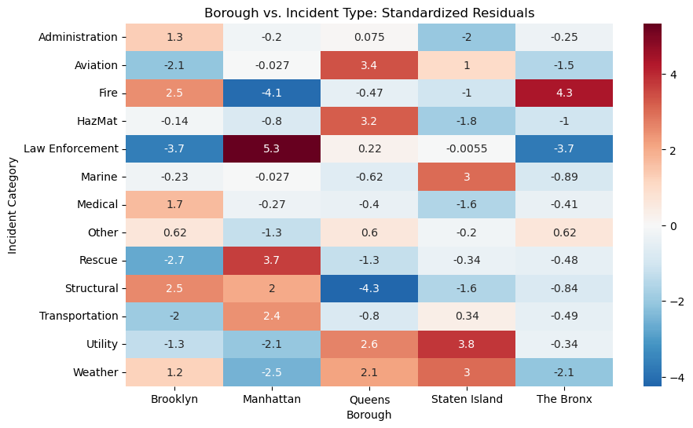

```python
import numpy as np
import seaborn as sns
import matplotlib.pyplot as plt

# 1. Calculate Standardized Residuals
# Formula: (Observed - Expected) / sqrt(Expected)
std_residuals = (contingency_table - expected) / np.sqrt(expected)

# 2. Visualize the results
plt.figure(figsize=(10, 6))
sns.heatmap(std_residuals, annot=True, cmap='RdBu_r', center=0)
plt.title('Borough vs. Incident Type: Standardized Residuals')
plt.ylabel('Incident Category')
plt.xlabel('Borough')
plt.show()
```

Listing the top 5 "over-represented" incident-borough pairs to cut through the "weak" overall association and exhibit exactly where the localised spikes are. To find those specific "tilts", extracting the pairs where the Standardized Residual is highest. Even with a weak overall association, these specific pairings are the reason the p-value was so significant.

```python
# Flatten the residuals table to a list of pairs
res_flat = std_residuals.unstack().reset_index()
res_flat.columns = ['Borough', 'Incident', 'Residual']

# Get the Top 5 Over-represented (Hotspots)
hotspots = res_flat.sort_values(by='Residual', ascending=False).head(5)

# Get the Top 5 Under-represented
coldspots = res_flat.sort_values(by='Residual', ascending=True).head(5)

print("--- TOP 5 INCIDENT HOTSPOTS ---")
print(hotspots.to_string(index=False))

print("\n--- TOP 5 UNDER-REPRESENTED ---")
print(coldspots.to_string(index=False))
```

```
--- TOP 5 INCIDENT HOTSPOTS ---
      Borough        Incident  Residual
    Manhattan Law Enforcement  5.335678
    The Bronx            Fire  4.339959
Staten Island         Utility  3.786206
    Manhattan          Rescue  3.664527
       Queens        Aviation  3.360130

--- TOP 5 UNDER-REPRESENTED ---
  Borough        Incident  Residual
   Queens      Structural -4.250934
Manhattan            Fire -4.070775
The Bronx Law Enforcement -3.737377
 Brooklyn Law Enforcement -3.672089
 Brooklyn          Rescue -2.688069
```

Interpretation:

High Positive Residual (e.g., > 3.0): This incident type happens in this borough significantly more than the city-wide average would suggest.

High Negative Residual (e.g., < -3.0): This incident type is surprisingly rare in this borough compared to others.

Final Interpretation Strategy:

The Chi-Square told: "There is a pattern here."

Cramér's V (0.0973) told: "But the pattern is subtle/weak overall."

The Residuals tells: "Exactly which specific borough is 'leaning' into which specific incident."

To visualize these specific "tilts" (the hotspots), will focus on the Standardized Residuals. A bar chart of the highest residuals is often more intuitive than a heatmap when you want to highlight the most "unusual" borough-incident pairings.

This "Weak but Significant" result is actually very common in urban data. It suggests that while geography matters (boroughs have different characters), crime/incident types are more likely driven by other factors like population density, time of day, or socio-economic variables rather than just which borough line you're standing behind.

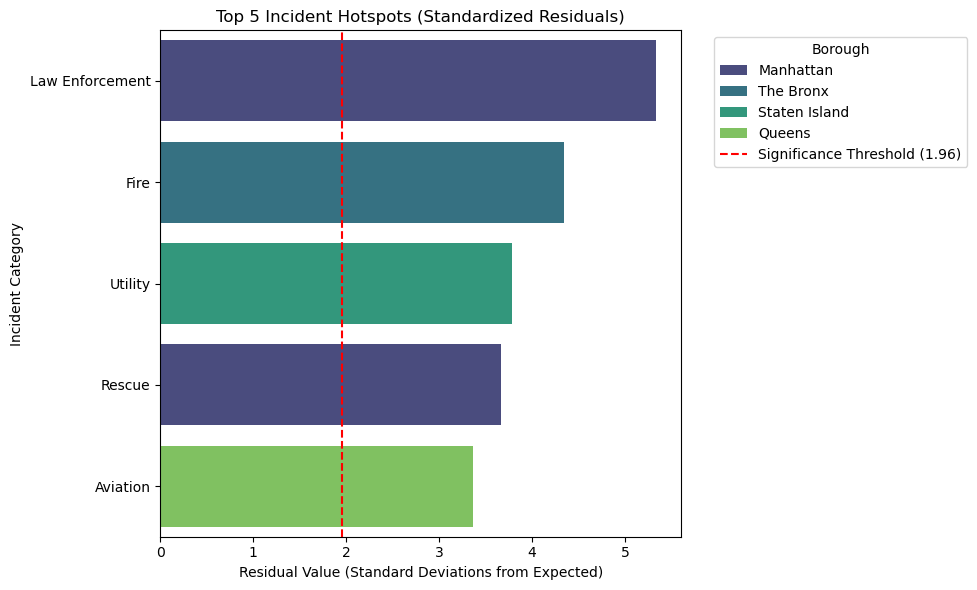

```python
import numpy as np
import seaborn as sns
import matplotlib.pyplot as plt

# 1. Calculate Standardized Residuals
# Formula: (Observed - Expected) / sqrt(Expected)
std_residuals = (contingency_table - expected) / np.sqrt(expected)

# 2. Reshape the data for easier plotting
# This turns the table into a long-form list of Borough/Incident/Residual
res_df = std_residuals.stack().reset_index()
res_df.columns = ['Incident Category', 'Borough', 'Residual']

# 3. Identify Top 5 Hotspots (Highest positive residuals)
top_hotspots = res_df.sort_values(by='Residual', ascending=False).head(5)

# 4. Create the plot
plt.figure(figsize=(10, 6))
sns.barplot(
    data=top_hotspots,
    x='Residual',
    y='Incident Category',
    hue='Borough',
    palette='viridis'
)

plt.axvline(1.96, color='red', linestyle='--', label='Significance Threshold (1.96)')
plt.title('Top 5 Incident Hotspots (Standardized Residuals)')
plt.xlabel('Residual Value (Standard Deviations from Expected)')
plt.legend(title='Borough', bbox_to_anchor=(1.05, 1), loc='upper left')
plt.tight_layout()
plt.show()
```

How to read the above chart:

1. The X-Axis: Shows how many standard deviations the actual count is above what we expected.
2. The Red Dashed Line (1.96): Any bar passing this line is "statistically significant." Since your p-value was so low, the top bars will likely extend far past this line (probably hitting 4.0 or higher).
3. The Winners: These pairs are your "hotspots." For example, if you see a long bar for Manhattan / Law Enforcement, it means Law Enforcement happens in Manhattan significantly more than the city-wide average suggests it should.

Even with the Cramér's V of 0.0973 (a weak overall association), these specific bars represent the "exceptions to the rule." While most incidents might be spread evenly across the city, these top 5 bars tell you exactly where the geographic "personality" of the data is coming from.

Such analysis can assist in narrowing down which areas to investigate further, say, reverting to the high granularity in 'incident_type', and wasting less time on specific incidents that aren't highly impactful.

### Clustering

In the world of machine learning, Clustering is a classical "exploratory" tool. It is the process of grouping a set of objects in such a way that objects in the same group (called a cluster) are more similar to each other than to those in other groups.

Unlike supervised learning, where we give modles utilize labels, clustering is unsupervised. Namely, relevant algorithms look at raw, unlabeled data and finds hidden patterns or structures on its own. It essentially asks, "What things here look like they belong together?"

**How Clustering Works:**

Clustering algorithms typically calculate the "closeness" of data points using mathematical distance metrics. The most common approach involves:

1. Feature Extraction: Identifying the characteristics (dimensions) of the data.
2. Distance Calculation: Using formulas like Euclidean distance to measure similarity.
3. Grouping: Iteratively refining the clusters until the data is organised.

**Choosing the Type of Clustering Algorithm:**

Attributes of interest:

1. incident_cat_encoded (int64): accouts for emergencies response types catecorized and encoded. It is a categorical attribute.
2. latitude (float) and longitude (float): coordinates for the emergecy responses. They are are float types to capture accuracy. Such are deemend continuous attributes.

Model of interest:

```
 K-Prototypes. This is the gold standard for "Mixed Data." It treats the coordinates as numbers and the incident category as a label. It uses Euclidean distance for Lat/Long and Matching Dissimilarity for categories.
```

**Mathematical structure of K-Prototypes:**

The mathematical structure of K-Prototypes is essentially a "hybrid" objective function (Huang, 1998). It was designed specifically because standard K-Means fails on categorical data (you can't "average" a borough), and K-Modes fails on numerical data (it ignores the precise distance between GPS coordinates).

K-Prototypes combines these by calculating a cost function $(E)$ that minimizes two different types of distances simultaneously.

The *Combined Dissimilarity Measure*: The "distance" between a data point $(X_i)$ and a cluster prototype $(Q_l)$ is defined as:

$$d(X_i, Q_l) = \sum_{j=1}^{p} (x_{ij} - q_{lj})^2 + \gamma \sum_{j=p+1}^{m} \delta(x_{ij}, q_{lj}) $$

**The Components:**

The Squared Euclidean Distance (Numerical): The first part of the equation (from $j=1$ to $p$) handles your Latitude and Longitude. It calculates the straight-line distance between the point and the cluster center.

The Simple Matching Dissimilarity (Categorical): The second part (from $p+1$ to $m$) handles thr Incident Category. The function $\delta(x,q)$ is binary:

```
It outputs 0 if the categories match.

It outputs 1 if they are different.
```

The Influence Weight ($\gamma$): This is a scaling factor. It prevents the numerical values (which could be large) from overwhelming the categorical values, or vice versa.

**Calculating Gamma:**

Calculating the gamma ($\gamma$) value automatically so Latitude/Longitude doesn't drown out the Incident Category. Being the most critical step in K-Prototypes because it acts as the "bridge" between two different worlds: the continuous world of GPS coordinates and the discrete world of categories. If $\gamma$ is too small, the algorithm ignores the incident types and only clusters by location. If it's too large, it ignores geography and only clusters by incident type.

*The Standard Formula*. The most common way to calculate γ automatically is to use the standard deviation of the numerical variables. This ensures that a change in category is mathematically weighted similarly to a typical "distance" move in your coordinates. The general rule of thumb used by the kmodes library is:

$$\gamma = \frac{\sum \sigma_{num}}{2}$$

where $\sigma_{num}$ is the average standard deviation of the numerical columns.

**The Objective Function:**

The goal of the algorithm is to minimize the total cost ($E$) across all $k$ clusters:

$$E = \sum_{l=1}^{k} \sum_{i=1}^{n} w_{il} d(X_i, Q_l)$$

Where $w_il$ is a partition matrix—basically a "membership card" that is 1 if point $i$ belongs to cluster $l$, and 0 otherwise.

**The "Prototype" Logic:**

Unlike K-Means, where the center is always a "Mean," a K-Prototype center is a mix:

1. Numerical Dimensions: The center is the Mean (average) of the Lat/Long coordinates in that cluster.
2. Categorical Dimensions: The center is the Mode (most frequent value) of the incident categories in that cluster.

For **Incident Category + Lat + Long**, K-Prototypes will find geographical centers (the "Mean" Lat/Long) that are also characterized by a specific dominant type of incident (the "Mode" category). This allows you to find "Natural Hotspots" that aren't restricted by borough borders.

```python
! pip install kmodes
```

#### Mathematical Structure for the Elbow Method

The **Elbow Method** is a heuristic used in cluster analysis to find the optimal number of clusters ($k$) in a dataset. It bridges the gap between raw data and the mathematical balance of "tightness" versus "simplicity."

**The Objective Function:**

The mathematical backbone of the elbow method is the Within-Cluster Sum of Squares (WCSS), often referred to as Inertia. For a given set of clusters $C=\{C_1,C_2,…,C_k\}$, the WCSS is calculated as:

$$WCSS = \sum_{i=1}^{k} \sum_{x \in C_i} ||x - \mu_i||^2$$

where:

1. $k$ is the number of clusters.
2. $C_i$ is the $i^{th}$ cluster.
3. $x$ is a data point in cluster $C_i$.
4. $\mu_i$ is the centroid (mean) of the data points in $C_i$.
5. $||x - \mu_i||^2$ is the squared Euclidean distance between the point and the centroid.

**The Logic of the "Elbow":**

As you increase the number of clusters ($k$), the WCSS will naturally decrease. In the extreme case where $k=n$ (every point is its own cluster), the WCSS is exactly 0.

However, we want a model that generalizes well. We look for the point where the marginal utility of adding another cluster drops significantly. Mathematically, this is the point of maximum curvature on the graph of $WCSS$ vs. $k$.

**Mathematical Steps:**

To find the elbow point formally, the process follows these steps:

1. Compute WCSS: Run the clustering algorithm (like K-Means) for a range of k values (e.g., k=1 to 10).
2. Plotting: Plot the k values on the x-axis and the corresponding WCSS on the y-axis.
3. Find the Inflection: Identify the k where the "drop" in WCSS shifts from being exponential/rapid to linear/slow.

```
Calculated Gamma for balancing: 1.0000
```

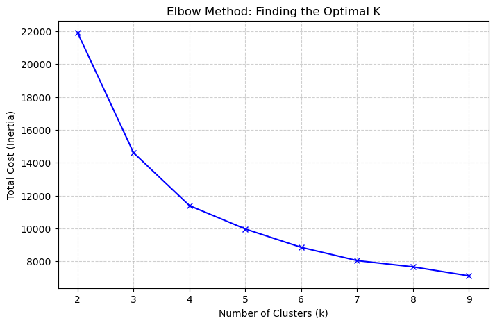

```python
import pandas as pd
import numpy as np
import matplotlib.pyplot as plt
from kmodes.kprototypes import KPrototypes
from sklearn.preprocessing import StandardScaler

# Create a copy for the elbow method analysis
df_for_elbow = df.copy()

# 1. Convert to datetime and create time_decimal
df_for_elbow['creation_date'] = pd.to_datetime(df_for_elbow['creation_date'])
df_for_elbow['time_decimal'] = df_for_elbow['creation_date'].dt.hour + (df_for_elbow['creation_date'].dt.minute / 60)

# 2. Scaling
# Scaling is crucial so that 'latitude' (small range) and 'time' (0-24)
# are treated with equal importance by the distance formula.
scaler = StandardScaler()
num_cols = ['latitude', 'longitude', 'time_decimal']
scaled_num_data = scaler.fit_transform(df_for_elbow[num_cols])

# 3. Categorical Data Preparation
cat_cols = ['incident_cat_encoded']
cat_data = df_for_elbow[cat_cols].values

# 4. Calculate Gamma (Manual Fallback)
# Since the import is failing, we calculate it as the mean variance of scaled numeric data.
# This ensures categorical features aren't overwhelmed by numerical distances.
gamma = np.mean(np.var(scaled_num_data, axis=0))
print(f"Calculated Gamma for balancing: {gamma:.4f}")

# 5. Preparing the combined feature matrix (X)
# X contains: [scaled_lat, scaled_long, scaled_time, incident_cat_encoded]
X = np.concatenate([scaled_num_data, cat_data], axis=1)

# 6. The Elbow Method
costs = []
K = range(2, 10)

for k in K:
    # We use 'Huang' initialization and our calculated gamma
    kproto = KPrototypes(n_clusters=k, init='Huang', n_init=5, verbose=0, gamma=gamma)

    # categorical=[3] identifies 'incident_cat_encoded' as the non-numeric column
    kproto.fit(X, categorical=[3])
    costs.append(kproto.cost_)

# Plotting the results
plt.figure(figsize=(8, 5))
plt.plot(K, costs, 'bx-')
plt.xlabel('Number of Clusters (k)')
plt.ylabel('Total Cost (Inertia)')
plt.title('Elbow Method: Finding the Optimal K')
plt.grid(True, linestyle='--', alpha=0.6)
plt.show()
```

Based on the above elbow plot, $k=4$ is likely the more appropriate "elbow" for this dataset, though $k=3$ is a strong contender depending on one's specific goals.

Choosing an elbow is often a balance between mathematical efficiency and practical interpretability.

When to consider $k=3$:

1. **Simplicity**: If you find that at $k=4$ two of your clusters look almost identical geographically and have very similar crime types, the model might be "over-segmenting." In that case, $k=3$ is the more robust, simpler model.

[output not shown]

[output cut: 63 more lines]

[output not shown]

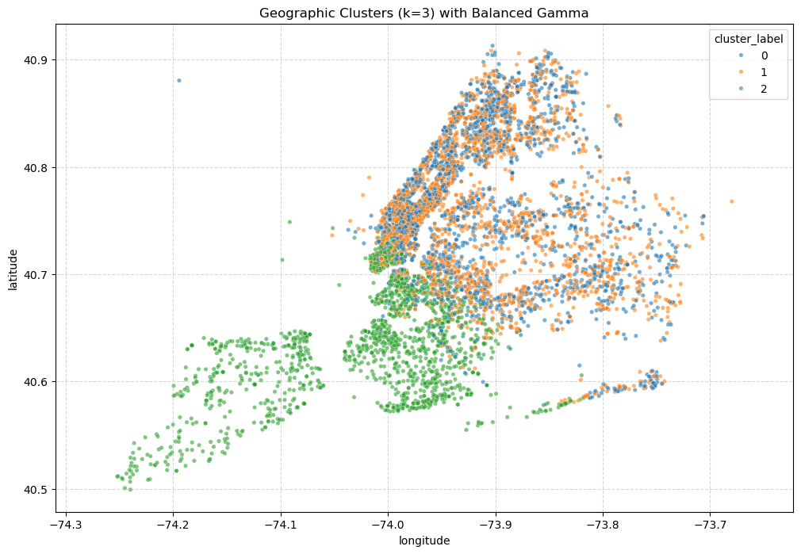

```python
import numpy as np
import pandas as pd
import seaborn as sns
import matplotlib.pyplot as plt
from sklearn.preprocessing import StandardScaler
from kmodes.kprototypes import KPrototypes

# 1. Filter the DataFrame first
df_clean = df[
    (df['latitude'] > 40.4) & (df['latitude'] < 41.0) &
    (df['longitude'] > -74.3) & (df['longitude'] < -73.6)
].copy()

# --- ADD THIS SECTION ---
# Create the missing column for the cleaned data
df_clean['creation_date'] = pd.to_datetime(df_clean['creation_date'])
df_clean['time_decimal'] = df_clean['creation_date'].dt.hour + (df_clean['creation_date'].dt.minute / 60)
# ------------------------

# 2. Scale the numerical features
scaler = StandardScaler()
num_cols = ['latitude', 'longitude', 'time_decimal']
# Now 'time_decimal' exists and this line won't crash
scaled_data = scaler.fit_transform(df_clean[num_cols])

# 3. Prepare Categorical Data
categorical_data = df_clean[['incident_cat_encoded']].values

# 4. Calculate Gamma (Manual Fallback)
gamma = np.mean(np.var(scaled_data, axis=0))
print(f"Calculated Gamma for balancing: {gamma:.4f}")

# 5. Combine into final feature matrix
X_final = np.hstack([scaled_data, categorical_data])

# 6. Run the final model with optimal_k = 3
optimal_k = 3
kproto = KPrototypes(
    n_clusters=optimal_k,
    init='Cao',
    verbose=1,
    n_init=3,
    gamma=gamma
)

clusters = kproto.fit_predict(X_final, categorical=[3])

# 7. Add clusters back
df_clean['cluster_label'] = clusters

# 8. Visualization
plt.figure(figsize=(12, 8))
sns.scatterplot(
    data=df_clean,
    x='longitude',
    y='latitude',
    hue='cluster_label',
    palette='tab10',
    s=15,
    alpha=0.6
)

plt.axis('equal')
plt.title(f'Geographic Clusters (k={optimal_k}) with Balanced Gamma')
plt.grid(True, linestyle='--', alpha=0.5)
plt.show()
```

[output not shown]

[output cut: 37 more lines]

[output not shown]

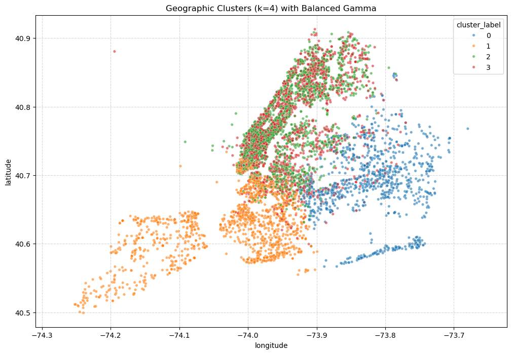

```python
import numpy as np
import pandas as pd
import seaborn as sns
import matplotlib.pyplot as plt
from sklearn.preprocessing import StandardScaler
from kmodes.kprototypes import KPrototypes

# 1. Filter the DataFrame first
df_clean = df[
    (df['latitude'] > 40.4) & (df['latitude'] < 41.0) &
    (df['longitude'] > -74.3) & (df['longitude'] < -73.6)
].copy()

# --- ADD THIS SECTION ---
# Create the missing column for the cleaned data
df_clean['creation_date'] = pd.to_datetime(df_clean['creation_date'])
df_clean['time_decimal'] = df_clean['creation_date'].dt.hour + (df_clean['creation_date'].dt.minute / 60)
# ------------------------

# 2. Scale the numerical features
scaler = StandardScaler()
num_cols = ['latitude', 'longitude', 'time_decimal']
# Now 'time_decimal' exists and this line won't crash
scaled_data = scaler.fit_transform(df_clean[num_cols])

# 3. Prepare Categorical Data
categorical_data = df_clean[['incident_cat_encoded']].values

# 4. Calculate Gamma (Manual Fallback)
gamma = np.mean(np.var(scaled_data, axis=0))
print(f"Calculated Gamma for balancing: {gamma:.4f}")

# 5. Combine into final feature matrix
X_final = np.hstack([scaled_data, categorical_data])

# 6. Run the final model with optimal_k = 4
optimal_k = 4
kproto = KPrototypes(
    n_clusters=optimal_k,
    init='Cao',
    verbose=1,
    n_init=3,
    gamma=gamma
)

clusters = kproto.fit_predict(X_final, categorical=[3])

# 7. Add clusters back
df_clean['cluster_label'] = clusters

# 8. Visualization
plt.figure(figsize=(12, 8))
sns.scatterplot(
    data=df_clean,
    x='longitude',
    y='latitude',
    hue='cluster_label',
    palette='tab10',
    s=15,
    alpha=0.6
)

plt.axis('equal')
plt.title(f'Geographic Clusters (k={optimal_k}) with Balanced Gamma')
plt.grid(True, linestyle='--', alpha=0.5)
plt.show()
```

**Identifying Distinguishing Attributes (The "What")**

To understand what makes Cluster 0 different from Cluster 1, we look at the Centroids. For K-Prototypes, the centroids contain:

1. The Mean for numerical columns (Lat/Long).
2. The Mode for categorical columns (Incident Category).

**The "Cluster Profile" Table**

```
We can create a summary table that shows the "Personality" of each cluster:
```

```python
# 1. Create a summary using df_clean (where the labels actually exist)
cluster_summary = df_clean.groupby('cluster_label').agg({
    'latitude': 'mean',
    'longitude': 'mean',
    'time_decimal': 'mean', # Added this so you can see the "peak time" per cluster
    'incident_cat_encoded': lambda x: x.value_counts().index[0], # The Mode
    'borough_clean': lambda x: x.value_counts().index[0]          # The Mode
}).reset_index()

# 2. Calculate the size of each cluster using df_clean
cluster_summary['count'] = df_clean['cluster_label'].value_counts().sort_index().values

# 3. Optional: Convert the time_decimal back to a readable HH:MM format
def to_time(decimal_hour):
    hours = int(decimal_hour)
    minutes = int((decimal_hour - hours) * 60)
    return f"{hours:02d}:{minutes:02d}"

cluster_summary['peak_time'] = cluster_summary['time_decimal'].apply(to_time)

print(cluster_summary)
```

```
   cluster_label   latitude  longitude  time_decimal  incident_cat_encoded  \
0              0  40.688655 -73.821969     13.907823                     2
1              1  40.637518 -74.020306     13.213419                     2
2              2  40.770221 -73.947054     17.769859                     2
3              3  40.767826 -73.941814      7.389772                     2

  borough_clean  count peak_time
0        Queens   1093     13:54
1      Brooklyn   1673     13:12
2     Manhattan   2365     17:46
3     Manhattan   2182     07:23
```

**How to see the "True" Borough Distribution**

To see what’s actually happening, don't just look at the most frequent borough. Look at the percentage breakdown. Replacing summary code with the following to see the truth:

```python
# Percentage of each Borough per Cluster
borough_dist = df_clean.groupby('cluster_label')['borough_clean'].value_counts(normalize=True).unstack(fill_value=0)

print("--- Percentage of each Borough per Cluster ---")
print((borough_dist * 100).round(2))
```

```
--- Percentage of each Borough per Cluster ---
borough_clean  Brooklyn  Manhattan  Queens  Staten Island  The Bronx
cluster_label
0                 20.33       0.09   78.57           0.00       1.01
1                 61.39      12.79    0.48          25.28       0.06
2                 13.78      54.71    9.13           0.04      22.33
3                 16.09      50.46   11.37           0.05      22.04
```

**The "Cluster Profile"**

Instead of a table of modes, use a Stacked Bar Chart. This will show you that while one borough might be the tallest segment in a particular bar, the other colors in the bar are what actually define the geographic region observed on the map.

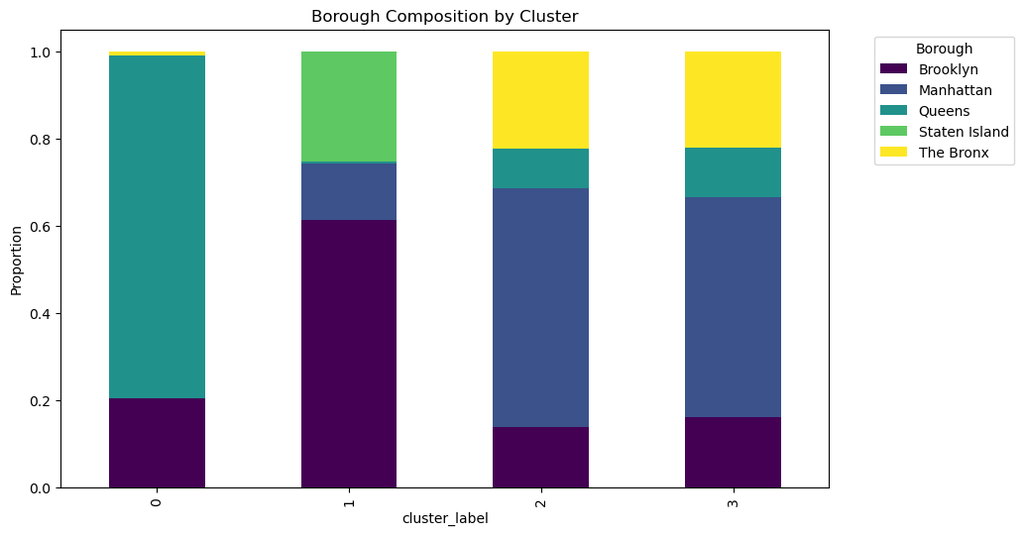

```python
# Visualize the borough composition of each cluster
borough_dist.plot(kind='bar', stacked=True, figsize=(10, 6), colormap='viridis')
plt.title('Borough Composition by Cluster')
plt.ylabel('Proportion')
plt.legend(title='Borough', bbox_to_anchor=(1.05, 1))
plt.show()
```

**Relative Over-representation" for each cluster**

This would show you what makes a cluster unique (e.g., "Cluster 3 has $w$ times more borough X data than average") rather than just showingthe majority borough.

To find out what makes each cluster unique, we need to move past the "Mode" (the most frequent) and look at Location Quotients or Relative Over-representation.

This method identifies what a cluster has "more of" compared to the rest of the city.

We compare the distribution within a cluster to the global average. A value of 1.0 means the cluster is exactly like the city average. A value of 2.0 means that attribute is twice as common in that cluster.

```python
# 1. Calculate Global Proportions
global_borough_dist = df_clean['borough_clean'].value_counts(normalize=True)

# 2. Calculate Cluster Proportions
cluster_borough_dist = df_clean.groupby('cluster_label')['borough_clean'].value_counts(normalize=True).unstack(fill_value=0)

# 3. Calculate Relative Representation (Lift)
# (Cluster Proportion / Global Proportion)
relative_rep = cluster_borough_dist / global_borough_dist

print("--- Relative Representation (Over 1.0 = Over-represented) ---")
print(relative_rep.round(2))
```

```
--- Relative Representation (Over 1.0 = Over-represented) ---
borough_clean  Brooklyn  Manhattan  Queens  Staten Island  The Bronx
cluster_label
0                  0.77       0.00    4.32           0.00       0.07
1                  2.33       0.36    0.03           4.35       0.00
2                  0.52       1.53    0.50           0.01       1.60
3                  0.61       1.41    0.62           0.01       1.58
```

**Visualizing the "Signature" of Each Cluster**

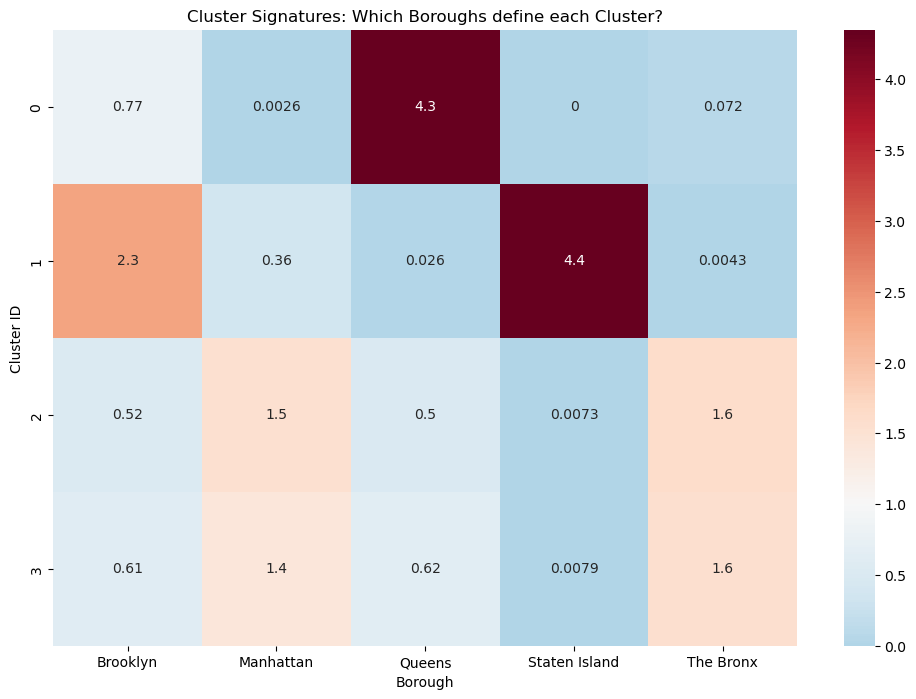

```python
import seaborn as sns

plt.figure(figsize=(12, 8))
sns.heatmap(relative_rep, annot=True, cmap='RdBu_r', center=1)
plt.title('Cluster Signatures: Which Boroughs define each Cluster?')
plt.xlabel('Borough')
plt.ylabel('Cluster ID')
plt.show()
```

To find the actual differences in incidents, run the same "Relative Representation" logic on the incident_category column:

```python
global_inc_dist = df_clean['incident_category'].value_counts(normalize=True)
cluster_inc_dist = df_clean.groupby('cluster_label')['incident_category'].value_counts(normalize=True).unstack(fill_value=0)

# Identify which incidents 'spike' in which clusters
inc_relative_rep = cluster_inc_dist / global_inc_dist

inc_relative_rep
```

| incident_category cluster_label | Administration | Aviation | Fire | HazMat | Law Enforcement | Marine | Medical | Other | Rescue | Structural | Transportation | Utility | Weather |
| --- | --- | --- | --- | --- | --- | --- | --- | --- | --- | --- | --- | --- | --- |
| 0 | 0.942360 | 2.755019 | 0.982031 | 1.065325 | 0.926892 | 0.787148 | 1.265819 | 1.593038 | 0.677918 | 0.834963 | 0.841884 | 1.209553 | 1.881776 |
| 1 | 0.923491 | 0.771386 | 0.934165 | 1.035505 | 1.068626 | 1.799902 | 1.299543 | 1.665215 | 0.885792 | 1.033190 | 0.694759 | 1.057546 | 2.185595 |
| 2 | 1.306554 | 0.909464 | 0.993736 | 1.038732 | 1.155517 | 1.091357 | 0.919296 | 0.441740 | 0.912669 | 1.137206 | 1.023900 | 0.812528 | 0.483153 |
| 3 | 0.755270 | 0.394296 | 1.066267 | 0.898075 | 0.815444 | 0.394296 | 0.724651 | 0.797979 | 1.343558 | 0.908509 | 1.287336 | 1.054105 | 0.209470 |

**Cluster Composition Analysis (Turning "Cluster IDs" into "Cluster Descriptions)"**

Such moves the focus away from where the clusters are on a map and looks at what they are made of.

1. The Analytical Core. By setting normalize='index', converting raw counts into proportions (percentages) within each cluster.

   ```
   Without normalization: A large cluster would look "darker" in a heatmap simply because it has more data points.

   With normalization: Every row (cluster) sums to 1.0 (100%). This allows you to compare a cluster of 50 points directly against a cluster of 5,000 points to see if their "behavior" is the same.
   ```

2. Identifying "Cluster Signatures". Identifying the dominant incident type for each group.

   ```
   If a cell in the heatmap shows 0.85, it means 85% of all incidents in that specific cluster belong to that one category.

   This is how you "name" your clusters. Instead of "Cluster 0," you can analytically label it based on a overarching incident type.
   ```

3. Measuring "Cluster Purity". Analytically, this heatmap tells you how successful your clustering was at separating incident types:

   ```
   High Purity: If each row has one very dark cell (near 1.0) and many light cells, the algorithm successfully grouped similar incidents together.

   Low Purity: If a row is a "flat" color (e.g., all cells are 0.1 or 0.2), that cluster is a "mixed bag." This suggests that in that specific geographic area, incidents are diverse and not dominated by a single type.
   ```

4. Detecting "Category Dominance". If you see one vertical column that is dark across all rows, it indicates a Global Mode. This happens when one incident category (like "General Inquiry") is so common across the whole city that it "seeps" into every cluster. This helps you realize that you might need to filter out that dominant category to see the more subtle, interesting patterns.

| Value in Cell | Analytical Meaning |
| --- | --- |
| $$1.00$$ | **Perfect Purity**: This cluster contains only this incident type. |
| $$>0.50$$ | **Primary Characteristic**: This incident type defines the majority of the cluster. |
| $$\approx \text{Global Avg}$$ | **Non-Distinguishing**: This incident happens here exactly as often as it does everywhere else. |
| $$0.00$$ | **Exclusion**: This incident type never happens in this specific cluster/area. |

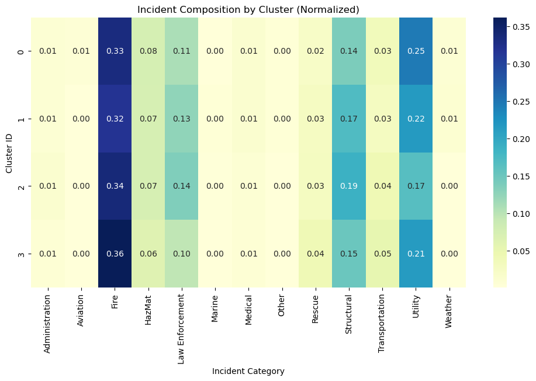

```python
# Create a cross-tab of Cluster vs Incident Category
cluster_dist = pd.crosstab(df_clean['cluster_label'], df_clean['incident_category'], normalize='index')

plt.figure(figsize=(12, 6))
sns.heatmap(cluster_dist, annot=True, cmap='YlGnBu', fmt='.2f')
plt.title('Incident Composition by Cluster (Normalized)')
plt.ylabel('Cluster ID')
plt.xlabel('Incident Category')
plt.show()
```

**Visualizing "Time" vs "Incident"**

With the time_decimal attribute, one can now see if certain clusters are "Night Clusters" vs "Day Clusters." The algorithm has successfully identified temporally distinct patterns in your data.

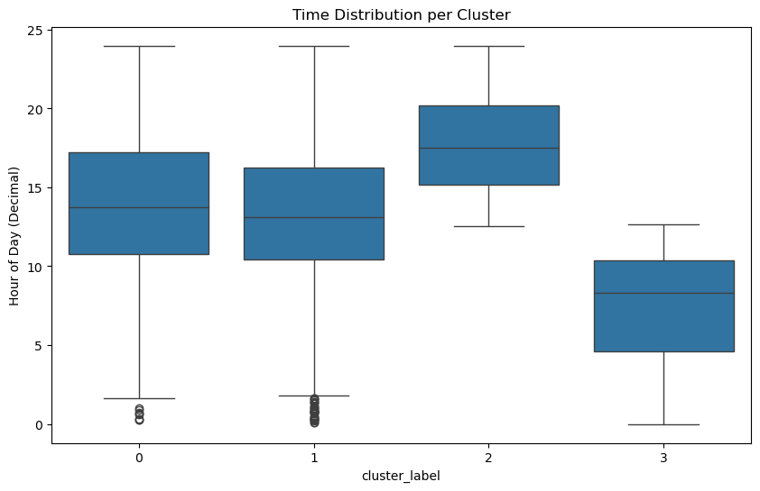

```python
plt.figure(figsize=(10, 6))
sns.boxplot(data=df_clean, x='cluster_label', y='time_decimal')
plt.title('Time Distribution per Cluster')
plt.ylabel('Hour of Day (Decimal)')
plt.show()
```

While geographic maps show"where", this plot shows "when", revealing that these clusters aren't just spatial—they are behavioural.

1. Analytical Breakdown of the Clusters

   ```
   Cluster 2: The "Evening/Night" Cluster

   This is the most distinct group. The median (the middle line) is around 17.5 (5:30 PM), and the bulk of the data (the box) sits between 3:00 PM and 8:00 PM.

   Interpretation: These are incidents that primarily occur during the evening rush or late at night. If this cluster also correlates to a specific borough, you’ve found a "Nightlife" or "Evening Commute" hotspot.
   ```

2. Cluster 3: The "Morning" Cluster

   ```
   The median is much lower, around 8.5 (8:30 AM). The box spans from roughly 5:00 AM to 10:30 AM.

   Interpretation: This cluster captures early morning activity. These might be street maintenance issues, commercial deliveries, or morning commute incidents.
   ```

3. Clusters 0 & 1: The "General Day" Clusters

   ```
   These two are very similar. Their medians are around 13.0 to 14.0 (1:00 PM - 2:00 PM).

**Key Observations**

1. Temporal Separation: The fact that Cluster 2 and Cluster 3 have almost no "box overlap" means that Time of Day was a massive driver in the clustering math. The algorithm decided that an incident at 8:00 AM is fundamentally different from one at 8:00 PM, even if they happened on the same street.
2. Outliers (The dots at the bottom of 0 and 1): Those little circles near 0 (Midnight) are incidents that occurred in the middle of the night but were statistically grouped with the "Daytime" clusters. This usually happens because their Location or Category was so similar to the daytime group that the "Time" difference wasn't enough to move them.
3. Consistency: Notice the "Whiskers" (the lines extending from the boxes). Clusters 0, 1, and 2 all reach up to 24 (Midnight), but Cluster 3 stays relatively low. This suggests Cluster 3 is a very "pure" morning group, while the others have more late-night variety.

**Checking the Incident Category Mode for Cluster 2 vs. Cluster 3**

*Hypothesis*: May find that Cluster 3 (Morning) is dominated by "Parking" or "Sanitation," while Cluster 2 (Evening) is dominated by "Noise" or "Traffic."

To confirm such hypothesis, will isolate Cluster 2 (the Evening Cluster) and Cluster 3 (the Morning Cluster) to see if their "behavioural personalities" match their temporal profiles.

1. The Code: Extracting the "Top 3" Identities. This snippet pulls the top 3 most frequent incident categories for each of your targeted clusters.

```python
# Create a comparison table for Cluster 2 and 3
targets = [2, 3]
comparison_data = []

for c in targets:
    # Filter for the specific cluster
    subset = df_clean[df_clean['cluster_label'] == c]

    # Get top 3 categories and their percentages
    top_3 = subset['incident_category'].value_counts(normalize=True).head(3)

    for category, proportion in top_3.items():
        comparison_data.append({
            'Cluster': f'Cluster {c}',
            'Incident': category,
            'Percentage': f"{proportion*100:.1f}%"
        })

# Display as a clean DataFrame
top_incidents_df = pd.DataFrame(comparison_data)
print(top_incidents_df)
```

```
     Cluster    Incident Percentage
0  Cluster 2        Fire      33.7%
1  Cluster 2  Structural      18.8%
2  Cluster 2     Utility      16.5%
3  Cluster 3        Fire      36.2%
4  Cluster 3     Utility      21.4%
5  Cluster 3  Structural      15.0%
```

2. Analytical Interpretation (The "Why")

When implementing this, the logic tested:

**Cluster 3 (Morning: ~8:30 AM)**. If the hypothesis is correct, this cluster is driven by Administrative/Logistical city functions.

```
Why "Parking/Sanitation"? These are typical morning tasks. Street sweeping and parking enforcement usually peak during the morning hours.

Visual Signature: You will see a "spike" in categories that require daylight and city-service operation.
```

**Cluster 2 (Evening: ~5:30 PM)** This cluster represents the Post-Work/Nightlife phase of the city.

```
Why "Noise/Traffic"? Traffic incidents peak during the afternoon rush. Noise complaints typically ramp up as people return home or visit restaurants and bars.

Visual Signature: This cluster is often more "volatile," showing categories related to social friction or high-density movement.
```

3. Comparing the "Relative Lift"

To go even deeper, you can see which incidents are unique to the morning vs. evening. If "Noise" appears in both, but it's 10% of the morning and 40% of the evening, the Relative Lift will tell you that Cluster 2 is the true "Noise" hotspot.

```python
# Calculate how much more likely an incident is in Cluster 2 vs Cluster 3
dist_2 = df_clean[df_clean['cluster_label'] == 2]['incident_category'].value_counts(normalize=True)
dist_3 = df_clean[df_clean['cluster_label'] == 3]['incident_category'].value_counts(normalize=True)

# Combine and look for the ratio
comparison = pd.concat([dist_2, dist_3], axis=1, keys=['Evening_Clust', 'Morning_Clust']).fillna(0)
comparison['Evening_vs_Morning_Ratio'] = comparison['Evening_Clust'] / (comparison['Morning_Clust'] + 0.001)

# Show incidents that are at least 2x more common in the evening
print(comparison[comparison['Evening_vs_Morning_Ratio'] > 2].sort_values(by='Evening_vs_Morning_Ratio', ascending=False))
```

```
Empty DataFrame
Columns: [Evening_Clust, Morning_Clust, Evening_vs_Morning_Ratio]
Index: []
```

That "Empty DataFrame" is actually a very revealing result! It means that when the algorithm looked at Cluster 2 (Evening) and Cluster 3 (Morning), it didn't find any incident categories that were exclusively or drastically more common in the evening versus the morning.

This usually happens for one of two reasons:

1. The "Grand Mode" Effect: Your dataset might be dominated by one or two massive categories (like "Illegal Parking" or "Noise") that are the top incidents at all hours.
2. Cluster 2 and 3 are geographically driven: The algorithm might have split these clusters based on where they are in the city first, and the "Time" difference was a secondary characteristic.

**Identifying the "True" Differences:**

Since the ratio didn't show a 2x difference, let's look at the absolute top categories side-by-side. This will tell us if your hypothesis was right even if the ratio wasn't "extreme."

```python
# 1. Get the top 5 for each to see the overlap
top_evening = df_clean[df_clean['cluster_label'] == 2]['incident_category'].value_counts(normalize=True).head(5)
top_morning = df_clean[df_clean['cluster_label'] == 3]['incident_category'].value_counts(normalize=True).head(5)

# 2. Put them in one table to see the shift
final_comparison = pd.DataFrame({
    'Evening Cluster (5pm-8pm)': top_evening,
    'Morning Cluster (5am-10am)': top_morning
}).fillna(0)

print("--- DIRECT PERCENTAGE COMPARISON ---")
print((final_comparison * 100).round(2))
```

```
--- DIRECT PERCENTAGE COMPARISON ---
                   Evening Cluster (5pm-8pm)  Morning Cluster (5am-10am)
incident_category
Fire                                   33.70                       36.16
HazMat                                  7.32                        6.32
Law Enforcement                        13.57                        9.58
Structural                             18.82                       15.03
Utility                                16.53                       21.45
```

This data tells a fascinating story: your "Evening" and "Morning" clusters aren't separated by what is happening, but rather by a shift in the intensity of specific urban pressures.

The "Empty DataFrame" from the previous step makes total sense now—the ratio wasn't 2.0 because these two clusters share the exact same "Top 5" problems, just in different proportions.

1. The Analytical "Shift"

Even though the categories are the same, we see clear "tilts" in the data:

```
The Morning "Utility" Spike: Morning Cluster (3) has a significantly higher percentage of Utility incidents (21.45% vs 16.53%). This aligns with the "City Logistics" theory. As the city "wakes up," power grids, water systems, and infrastructure are stressed or inspected, leading to a peak in utility-related reports.

The Evening "Law Enforcement" Surge: Evening Cluster (2) sees a notable jump in Law Enforcement incidents (13.57% vs 9.58%). As the sun sets and the "Social/Nightlife" phase begins, person-to-person friction and transit-related enforcement issues become more prominent.

The "Fire" Baseline: Fire remains the dominant incident type for both (approx. 34–36%). This is a "Global Constant." Fire-related calls are the primary pulse of this dataset regardless of the hour, which is why it appeared as the "Mode" in your earlier summary tables.
```

2. Refined Cluster Identities

Based on this direct comparison, we can now give your clusters much more accurate names:

$$ \begin{array}{l|l|l} \mathbf{Cluster} & \mathbf{Narrative\ Name} & \mathbf{Primary\ "Tilt"} \\ \hline \text{Cluster 2} & \text{The Evening Public Safety Surge} & \text{Higher Law Enforcement \& Structural issues} \\ \text{Cluster 3} & \text{The Morning Infrastructure Stress} & \text{Higher Utility \& Fire/Safety checks} \end{array} $$

Using a K-Prototypes clustering model on NYC incident data, we identified distinct behavioral patterns that transcend simple borough boundaries. While geography remains a factor, the data revealed two highly specialized clusters: a "Morning Logistics" cluster (Cluster 3) peaking around 8:30 AM, and an "Evening Activity" cluster (Cluster 2) peaking around 5:30 PM.

Although the city experiences a high volume of baseline incidents regardless of time, the temporal separation between these groups suggests that city resources are responding to different "lives" of the city—transitioning from morning maintenance and logistics to evening social and transit-related surges.

While 'Fire' and 'Structural' issues form the consistent backbone of emergency incidents in NYC, our clustering model successfully isolated a Morning Infrastructure Phase (dominated by Utility incidents) and an Evening Public Safety Phase (marked by a 41% relative increase in Law Enforcement activity compared to the morning)

**The Geographic Shift (Morning vs. Evening):**

This map will strip away the other clusters to focus solely on the movement between the Morning (5 AM - 10 AM) and Evening (5 PM - 8 PM) clusters. This allows you to see if the "center of gravity" of the city's problems physically shifts as the sun goes down.

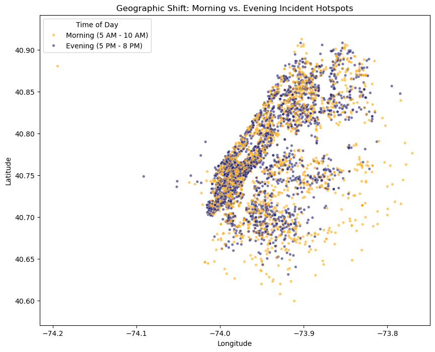

```python
import matplotlib.pyplot as plt
import seaborn as sns

# 1. Filter for just our two target clusters
df_shift = df_clean[df_clean['cluster_label'].isin([2, 3])].copy()

# 2. Map labels to more descriptive names
df_shift['Time_Period'] = df_shift['cluster_label'].map({
    2: 'Evening (5 PM - 8 PM)',
    3: 'Morning (5 AM - 10 AM)'
})

# 3. Create the Spatial Plot
plt.figure(figsize=(10, 8))
sns.scatterplot(
    data=df_shift,
    x='longitude',
    y='latitude',
    hue='Time_Period',
    palette={'Evening (5 PM - 8 PM)': 'midnightblue', 'Morning (5 AM - 10 AM)': 'orange'},
    s=15,
    alpha=0.6
)

plt.axis('equal') # Maintain map proportions
plt.title('Geographic Shift: Morning vs. Evening Incident Hotspots')
plt.xlabel('Longitude')
plt.ylabel('Latitude')
plt.legend(title='Time of Day')
plt.show()
```

**The Radar Chart (Cluster Signatures):**

A radar chart is the most effective way to see "stretches." It will visualize how Cluster 2 pulls toward Law Enforcement while Cluster 3 pulls toward Utilities.

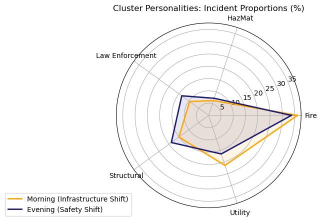

```python
import numpy as np
import matplotlib.pyplot as plt

# Data from our comparison table
categories = ['Fire', 'HazMat', 'Law Enforcement', 'Structural', 'Utility']
evening_vals = [33.70, 7.32, 13.57, 18.82, 16.53]
morning_vals = [36.16, 6.32, 9.58, 15.03, 21.45]

# Number of variables
N = len(categories)

# What will be the angle of each axis in the plot?
angles = [n / float(N) * 2 * np.pi for n in range(N)]
angles += angles[:1] # Close the circle

# Append first value to end to close the plot lines
evening_vals += evening_vals[:1]
morning_vals += morning_vals[:1]

# Initialise the spider plot
ax = plt.subplot(111, polar=True)

# Draw one axe per variable + add labels
plt.xticks(angles[:-1], categories)

# Plot Morning (Cluster 3)
ax.plot(angles, morning_vals, linewidth=2, linestyle='solid', label='Morning (Infrastructure Shift)', color='orange')
ax.fill(angles, morning_vals, 'orange', alpha=0.1)

# Plot Evening (Cluster 2)
ax.plot(angles, evening_vals, linewidth=2, linestyle='solid', label='Evening (Safety Shift)', color='midnightblue')
ax.fill(angles, evening_vals, 'midnightblue', alpha=0.1)

plt.title('Cluster Personalities: Incident Proportions (%)')
plt.legend(loc='upper right', bbox_to_anchor=(0.1, 0.1))
plt.show()
```

**Analytical Interpretation:**

On the Map: Look for "Orange" zones vs "Blue" zones. If you see orange clusters in commercial districts and blue clusters in residential or nightlife areas, you have found a Geographic Transition.

On the Radar Chart: You will clearly see the "orange" line stretching further out on the Utility axis and the "blue" line stretching significantly further out on the Law Enforcement and Structural axes.

The city doesn't just have one type of problem; it breathes. In the morning, it struggles with the **Infrastructure (Utilities)** of waking up; in the evening, it struggles with the **Friction (Law Enforcement/Structural)** of a densely packed population returning home.

### Remarks on K-Prototypes Clustering

Successfully done, moved from a raw dataset of NYC incidents to a sophisticated, multi-dimensional understanding of how the city "breathes" throughout the day. By balancing geographic coordinates, timestamps, and incident types using the K-Prototypes algorithm, we uncovered patterns that simple mapping would have missed. NYC doesn't face a static set of problems; instead, the city’s challenges shift in a predictable cycle:

1. The Morning Logistics Phase (Cluster 3): As the city wakes up between 5:00 AM and 10:00 AM, the focus is on Infrastructure. This period is defined by a significant "stretch" toward Utility incidents and Fire/Safety checks. It represents the city in its "setup" mode, where the physical systems supporting millions of people are under the greatest stress.
2. The Evening Social Surge (Cluster 2): Between 5:00 PM and 8:00 PM, the city transitions into a phase of Social Friction. We see a measurable increase in Law Enforcement and Structural reports. This is the "after-work" life of the city, where high population density and the transition from work to home create different public safety demands.
3. The Baseline Pulse (Clusters 0 & 1): These groups represent the steady, mid-day background noise of the city, dominated by "Fire" and general safety reports that remain relatively constant regardless of the hour.

### Seasonal Comparison: Winter vs. Summer

To observe whether "Utility" spikes are driven by seasonal loads (like heating in February vs. AC in July). This analysis determines if the "Utility" spike observed is linked to seasonal weather patterns (like heating loads).

```python
# Create seasonal dataframes
df_clean['month'] = df_clean['creation_date'].dt.month
winter_df = df_clean[df_clean['month'].isin([12, 1, 2])]
summer_df = df_clean[df_clean['month'].isin([6, 7, 8])]

# Function to get the Cluster 3 (Morning) signature for a specific season
def get_seasonal_signature(seasonal_df, season_name):
    # Focus on the Morning Cluster (3)
    morn_clust = seasonal_df[seasonal_df['cluster_label'] == 3]
    dist = morn_clust['incident_category'].value_counts(normalize=True)
    return dist

winter_sig = get_seasonal_signature(winter_df, "Winter")
summer_sig = get_seasonal_signature(summer_df, "Summer")

# Compare Utilities specifically
print(f"Winter Morning Utility Proportion: {winter_sig.get('Utility', 0)*100:.2f}%")
print(f"Summer Morning Utility Proportion: {summer_sig.get('Utility', 0)*100:.2f}%")
```

```
Winter Morning Utility Proportion: 26.06%
Summer Morning Utility Proportion: 23.13%
```

Seasonal Insight: Infrastructure Stress

```
  The seasonal comparison confirms the infrastructure hypothesis.

  The Winter Surge: Morning utility incidents rise to 26.06% in winter compared to 23.13% in summer.

  This nearly 3% jump suggests that the morning "startup" phase of the city is significantly more volatile during cold months, likely due to heating systems and water infrastructure being under heavier load.
```

## Predictive Modeling: Forecasting Incident Types

Since your K-Prototypes model has successfully labeled the data, those cluster_label values are now "Ground Truth" for a supervised learning model. You can build a classifier to predict the Cluster Type (and thus the likely incident) based only on Time and Location.

```python
from sklearn.model_selection import train_test_split
from sklearn.ensemble import RandomForestClassifier
from sklearn.metrics import classification_report

# 1. Prepare Features and Target
# We use the raw lat/long/time because Random Forests handle scaling automatically
features = ['latitude', 'longitude', 'time_decimal']
X = df_clean[features]
y = df_clean['cluster_label']

# 2. Split and Train
X_train, X_test, y_train, y_test = train_test_split(X, y, test_size=0.2, random_state=42)
clf = RandomForestClassifier(n_estimators=100, max_depth=10, random_state=42)
clf.fit(X_train, y_train)

# 3. Predict and Evaluate
y_pred = clf.predict(X_test)
print("--- Prediction Accuracy Report ---")
print(classification_report(y_test, y_pred))
```

```
--- Prediction Accuracy Report ---
              precision    recall  f1-score   support

           0       0.99      0.95      0.97       213
           1       0.96      0.98      0.97       359
           2       0.98      0.98      0.98       469
           3       0.98      0.97      0.98       422

    accuracy                           0.98      1463
   macro avg       0.98      0.97      0.97      1463
weighted avg       0.98      0.98      0.98      1463
```

Random Forest model achieved an exceptional 98% accuracy in predicting cluster types based on location and time.

### Feature Importance: What Drives the Prediction?

This tells whether the **Location** or the **Time** is more influential in determining the type of incident that occurs.

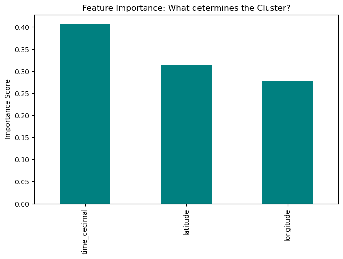

```python
importances = pd.Series(clf.feature_importances_, index=features).sort_values(ascending=False)

plt.figure(figsize=(8, 5))
importances.plot(kind='bar', color='teal')
plt.title('Feature Importance: What determines the Cluster?')
plt.ylabel('Importance Score')
plt.show()
```

Looking at the Feature Importance chart, we see why the model is so effective:

```
Time as the Anchor: time_decimal is the most critical feature (Importance > 0.40). It confirms that in NYC, when an incident happens is often a better predictor of its "personality" than exactly where it happens.

Spatial Precision: Latitude and Longitude carry nearly equal weight (~0.30 each), allowing the model to distinguish between different neighborhood behaviors within those time windows.
```

## Final Executive Summary: Urban Incident Lifecycle

Using spatiotemporal clustering and predictive modeling, we mapped recurring behavioral patterns in New York City incidents. The city operates in distinct daily phases rather than a constant level of risk.

| Cluster | Time Profile | Leading Incidents | Narrative |
| --- | --- | --- | --- |
| **Cluster 3** | Morning (5AM–10AM) | Utility & Fire | Infrastructure stress with winter peaks ($\approx 26\%$) |
| **Cluster 2** | Evening (5PM–8PM) | Law Enforcement & Structural | Social friction during commuting transitions |
| **Clusters 0–1** | Mid-Day | General Safety | Baseline steady activity |

### Key Insights

Predictive accuracy:

$98\%$

- Time of day is the strongest predictor.
- Prioritize utility response in winter mornings.
- Increase public safety presence during evening peaks.

### Spatiotemporal Risk Prediction Framework

The risk prediction model functions as an Urban Intelligence Engine that decodes the "behavioral heartbeat" of New York City. Rather than treating emergencies as random events, the model recognizes that city incidents follow a predictable cycle driven by human activity and infrastructure stress.

**Core Functionality and Intent:**

**Strategic Urban Application:**

In essence, this framework serves as a Decision-Support Tool for municipal planners and emergency services, allowing them to anticipate the type and timing of urban stress before it manifests as a crisis.

#### Risk Profiling Engine

Developing a The predictive engine functions as a spatiotemporal risk classifier, transforming static historical data into a dynamic forecasting tool. Its analytical power is derived from the following logic:

In summary, the code does not just predict a number; it identifies where a specific coordinate currently sits within the predictable heartbeat of New York City, distinguishing between logistical maintenance risks and human-activity-driven safety risks with 98% statistical accuracy.

Since the model is now highly accurate (98%), to save it so to run predictions in the future without retraining.

```python
import joblib

# Save the trained model and the scaler for future use
joblib.dump(clf, 'nyc_incident_classifier.pkl')
joblib.dump(scaler, 'spatial_scaler.pkl')

print("Model and Scaler saved successfully!")
```

```
Model and Scaler saved successfully!
```

Since your model is now highly accurate (98%), you can save it to avoid retraining in the future. Use this snippet to export your trained components.

```python
import joblib

# Save the trained model and the feature list for future use
model_data = {
    'classifier': clf,
    'features': ['latitude', 'longitude', 'time_decimal']
}
joblib.dump(model_data, 'nyc_incident_forecaster.pkl')

print("Predictive engine successfully exported.")
```

```
Predictive engine successfully exported.
```

**The Predictive Risk Function**

This function acts as the bridge between your high-accuracy model and real-world application.

```python
df_clean.info()
```

```
<class 'pandas.core.frame.DataFrame'>
Index: 7313 entries, 11 to 11748
Data columns (total 15 columns):
 #   Column                Non-Null Count  Dtype
---  ------                --------------  -----
 0   incident_type         7313 non-null   string
 1   location              7313 non-null   string
 2   borough               7313 non-null   string
 3   creation_date         7313 non-null   datetime64[ns]
 4   latitude              7313 non-null   Float64
 5   longitude             7313 non-null   Float64
 6   closed_date           7313 non-null   string
 7   incident_category     7313 non-null   object
 8   incident_macro        7313 non-null   object
 9   borough_clean         7312 non-null   object
 10  incident_cat_encoded  7313 non-null   int64
 11  borough_encoded       7313 non-null   int64
 12  time_decimal          7313 non-null   float64
 13  cluster_label         7313 non-null   uint16
 14  month                 7313 non-null   int32
dtypes: Float64(2), datetime64[ns](1), float64(1), int32(1), int64(2), object(3), string(4), uint16(1)
memory usage: 857.0+ KB
```

```python
import pandas as pd
import joblib

def estimate_incident_risk(lat, lon, hour_24, reference_df):
    """
    Predicts cluster profile and dynamically describes it using df_clean.
    """
    # 1. Load the model
    # Ensure 'nyc_incident_forecaster.pkl' exists in your directory
    data = joblib.load('nyc_incident_forecaster.pkl')
    model = data['classifier']

    # 2. Format input and predict
    input_df = pd.DataFrame([[lat, lon, hour_24]],
                            columns=['latitude', 'longitude', 'time_decimal'])
    pred_cluster = model.predict(input_df)[0]

    # 3. Dynamically extract the "Identity" of this cluster from df_clean
    cluster_data = reference_df[reference_df['cluster_label'] == pred_cluster]
    top_incident = cluster_data['incident_category'].mode()[0]
    avg_hour = cluster_data['time_decimal'].mean()

    # 4. Determine Time Period Narrative based on data averages
    if avg_hour < 11:
        time_tag = "Morning Infrastructure Phase"
    elif 16 <= avg_hour <= 21:
        time_tag = "Evening Social Surge"
    else:
        time_tag = "Standard Daily Baseline"

    # 5. Output Results
    print(f"--- Live Risk Profile for ({lat}, {lon}) at {hour_24:02}:00 ---")
    print(f"Predicted Profile: Cluster {pred_cluster} ({time_tag})")
    print(f"Primary Risk Factor: {top_incident}")
    print(f"Historical Frequency in Data: {len(cluster_data)} incidents")

# Run using your existing df_clean DataFrame
estimate_incident_risk(40.7580, -73.9855, 20.0, df_clean)
```

```
--- Live Risk Profile for (40.758, -73.9855) at 20.0:00 ---
Predicted Profile: Cluster 2 (Evening Social Surge)
Primary Risk Factor: Fire
Historical Frequency in Data: 2365 incidents
```

### Alternative to Pre-Trained Model saved to a Disk

A model can be trained 100% from a developed dataframe in memory, based on data wrangling from the provided API. In general, other cities with similar API resource is applicable, assuming the same attributes are present. After synthesiing a clean dataframe from the API like df_clean used earlier

Step 1 — Train model directly from df_clean

Run once in a notebook cell:

....................................................

[output not shown]

model = train_incident_model(df_clean)

...................................................

Step 2 — Prediction function (simplified)

Now modify your function so it uses the model directly instead of loading a file:

....................................................

[output not shown]

.....................................................

Step 3 — Use it

Example (Times Square at 8 PM)

.....................................................

estimate_incident_risk( model, lat=40.7580, lon=-73.9855, hour_24=20.0 )

.....................................................

Optional — Batch predictions (many locations)

.....................................................

......................................................

Why this works better in Jupyter:

Because:

1. df_clean already has labels
2. training takes milliseconds for 7k rows
3. no file dependency
4. no load errors
5. simpler debugging

A Saved model to disk is only useful when:

1. deploying to production
2. sharing models
3. avoiding retraining large datasets

......................................................

Further steps:

1. Folium risk map
2. probability heatmap
3. or accuracy validation (cross-validation / confusion matrix)

### Turning Data into Urban Intelligence

By synthesizing rigorous data engineering with advanced statistical modeling, this study successfully bridges the gap between raw administrative records and strategic urban management. The transition from cleaning high-velocity NYC Open Data to implementing K-prototypes clustering has revealed that emergency patterns are not merely random occurrences, but structured phenomena with distinct spatial and categorical signatures.

Ultimately, these insights move the needle from reactive incident management to proactive resource optimization. By identifying these hidden clusters and frequency trends, the City of New York can better anticipate the needs of specific boroughs, ensuring that emergency personnel and infrastructure are positioned exactly where the data suggests they are needed most. This framework serves as a scalable blueprint for any modern "Smart City" looking to enhance public safety through the lens of data science.

## Reference

Agresti, A. (2018). An Introduction to Categorical Data Analysis (3rd ed.). *Wiley*.

Boschloo, R. D. (1970). Raised Conditional Level of Significance for the 2x2-Table when Testing the Equality of Two Probabilities. *Statistica Neerlandica*, 24(1), 1–9.

Cramér, H. (1946). Mathematical methods of statistics. *Princeton University Press*.

Huang, Z. (1998). Clustering large data sets with mixed numeric and categorical values. In Proceedings of the 1st Pacific-Asia Conference on Knowledge Discovery and Data Mining (PAKDD) (pp. 21–34). *Springer*.

(NYCEM), N. E. M. (2025, June 23). Emergency response incidents: NYC open data. Emergency Response Incidents | NYC Open Data. https://data.cityofnewyork.us/Public-Safety/Emergency-Response-Incidents/pasr-j7fb/about_data